# Loan Approval

Loan Approval is the process for the lender to deciding if borrower qualify for loan or not, In this project we want to make Loan Approval model to determine if borrower can success to loan or not using Machine Learning model. This is the step to make this project

## Table of Contents

### Read Data

```python
import pandas as pd
data=pd.read_csv("C:/Users/User/Documents/loan_apro.csv")
data.shape
data.head
```

```
<bound method NDFrame.head of           id  person_age  person_income person_home_ownership  \
0          0          37          35000                  RENT
1          1          22          56000                   OWN
2          2          29          28800                   OWN
3          3          30          70000                  RENT
4          4          22          60000                  RENT
...      ...         ...            ...                   ...
58640  58640          34         120000              MORTGAGE
58641  58641          28          28800                  RENT
58642  58642          23          44000                  RENT
58643  58643          22          30000                  RENT
58644  58644          31          75000              MORTGAGE

       person_emp_length loan_intent loan_grade  loan_amnt  loan_int_rate  \
0                    0.0   EDUCATION          B       6000          11.49
```

[output cut: 38 more lines]

```python
data_apr=data[data['loan_status']==0]
data_apr.iloc[0,:]
```

```
id                                    0
person_age                           37
person_income                     35000
person_home_ownership              RENT
person_emp_length                   0.0
loan_intent                   EDUCATION
loan_grade                            B
loan_amnt                          6000
loan_int_rate                     11.49
loan_percent_income                0.17
cb_person_default_on_file             N
cb_person_cred_hist_length           14
loan_status                           0
Name: 0, dtype: object
```

There're 58645 rows and 13 columns

### Check Missing Value and Data Duplicate

```python
data.isnull().sum()
```

```
id                            0
person_age                    0
person_income                 0
person_home_ownership         0
person_emp_length             0
loan_intent                   0
loan_grade                    0
loan_amnt                     0
loan_int_rate                 0
loan_percent_income           0
cb_person_default_on_file     0
cb_person_cred_hist_length    0
loan_status                   0
dtype: int64
```

```python
dup=data.duplicated().sum()
dup
```

```
np.int64(0)
```

Based on result, there's no data duplicated and missing value in this dataset

### EXPLANATORY DATA ANALYSIS

**1. Check the categorical data**

```python
data_cat=data.select_dtypes(include=['object']).columns.tolist()
for i in data_cat:
    print(f"variable {i} has item : {data[i].unique().tolist()}")
```

```
variable person_home_ownership has item : ['RENT', 'OWN', 'MORTGAGE', 'OTHER']
variable loan_intent has item : ['EDUCATION', 'MEDICAL', 'PERSONAL', 'VENTURE', 'DEBTCONSOLIDATION', 'HOMEIMPROVEMENT']
variable loan_grade has item : ['B', 'C', 'A', 'D', 'E', 'F', 'G']
variable cb_person_default_on_file has item : ['N', 'Y']
```

There're are four categorical in this dataset

Person home ownership

the type of owning a house, this variable have four item like renting (paying money for use property), own (buy the house), mortgage (its like paying property monthly/ we use credit method payment), and the last is Other. We can use owning house status to determine economy stability, for example OWn house is more stabil than rent or mrotgage since own its not making payment no more.

Loan intent

>the purpose of we loan to the bank, there're many reason like for educational, medical, and home impovement. The bankers is considered this because it can determine the risk of loan, for example the borrower loan the money for personal is more higher risk than venture (businees reason) because the banker dont know the ability of borrower to pay the loan for personal reason

loan grade

its like rating from banker for loan approval, from A is lower risk and E is higher risk, more higher the risk, less loan approval banker to decide

CB person on file

its like the borrower have crediit history in the banker, if they have, it depend other factor like credic score or payment history, if the result is good, higher chance loan approval and we can get lower interest rate. if we not have cb on file, lowe loan approval since the banker cant sae payment history, even loan is approved, the borrower will get higher interest rate

```python
from matplotlib import pyplot as plt
import numpy as np
#get data categorical
data_cat=data.select_dtypes(include=['object']).columns.tolist()
#make function of plot categorical
def make_plot(x,y):
    tab=data[y].value_counts().sort_values(ascending=True)
    x_data=tab.values
    y_data=tab.index
    #if nuique value just two we make pie chart
    if len(data[y].unique().tolist())==2:
        x.pie(x_data,labels=y_data,autopct='%1.1f%%',wedgeprops=dict(width=0.3))
        x.set_title(y.replace("_"," "),loc='left')
    #we make barh
    else:
        plot_bar=x.barh(y_data,x_data,color='lightblue')
        x.spines['top'].set_visible(False)
        x.spines['right'].set_visible(False)
        x.spines['bottom'].set_visible(False)
        for i,j in zip(x_data,y_data):
            x.text(i+20,j,f"{i}",fontweight='bold')
        x.set_title(y.replace("_"," "),loc='left')
        x.set_xticklabels([])
        x.set_xticks([])
```

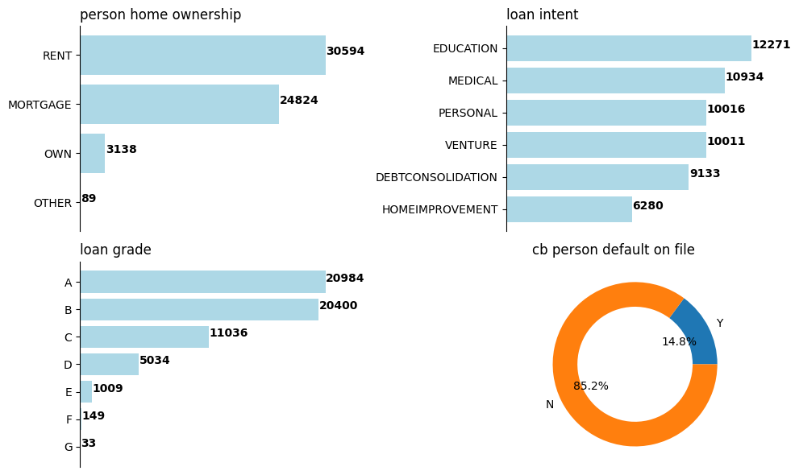

```python
fig,ax=plt.subplots(2,2,figsize=(10,6))
for (i,j),k in zip([(i,j) for i in range(2) for j in range(2)],data_cat):
    pl=make_plot(ax[i][j],k)
plt.tight_layout()
```

#### Explanantion

- most peope who joined loan approval stil rent a house, following mortgage house and owning house. we belive based on this the economy of people who joined loan approval is middle to low economy level.
- grad A and B in this dataset are the most loan grade that borrower have, The loan grade is good so the economy of lender most is stable since this is grade of lower risk loan.
- Educational, following medical and personal, it means that loan approval its likely low because educational medical and personal are high risk and the lender have little possibility to get the payment or they have no guarantee for the payment of loan
- Cb person default on file of NO is higher than yess, so the borrower most come for new user.

**2. Check Numerical Variable**

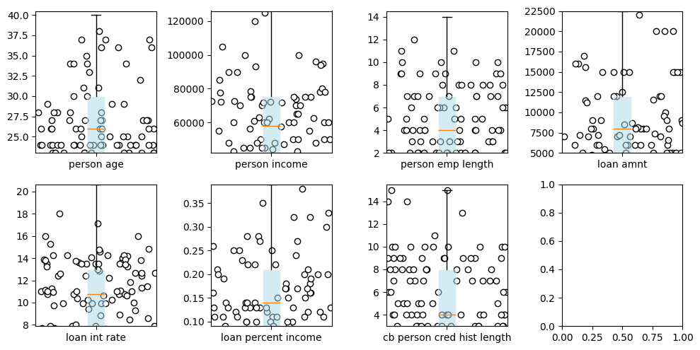

```python
#get numerical variable
data_num=data.select_dtypes(exclude=['object']).columns.tolist()
data_num_bar=[ i for i in data_num if i!= 'id' and i!='loan_status']
import numpy as np
fig,ax=plt.subplots(2,4,figsize=(10,5))
for (i,j),k in zip([(i,j) for i in range(2) for j in range(4)],data_num_bar):
    amb=data[k]
    box=ax[i][j].boxplot(amb,patch_artist=True,showfliers=False,boxprops=dict(facecolor='lightblue',edgecolor='white',alpha=0.5))
    if not box['boxes']:
        ax[i,j].axis('off')
    else:
        ax[i][j].set_xticklabels([k.replace("_"," ")])
        q1=np.percentile(amb,25)
        q3=np.percentile(amb,75)
        upper=q3+(1.5*(q3-q1))
        ax[i,j].set_ylim([q1,upper])
        krx=ax[i,j].get_xlim()
        li=[]
        #make a random coordination
        while len(li)<100:
            rand=np.random.randint(0,len(amb))
            get_data=amb[rand]
            li.append(get_data)

        for l in li:
            kor=np.random.uniform(krx[0],krx[1])
            ax[i,j].scatter(kor,l,marker='o',color='white',edgecolors='black')

plt.tight_layout()
```

#### Explanation

they are many number of numerical variable, for example

Person age

Based on the result the age of borrowers between 25 - 30 years, the young man/woman

Peson Income

Person Employee Length

Loan Amount

The Loan Intent Rate

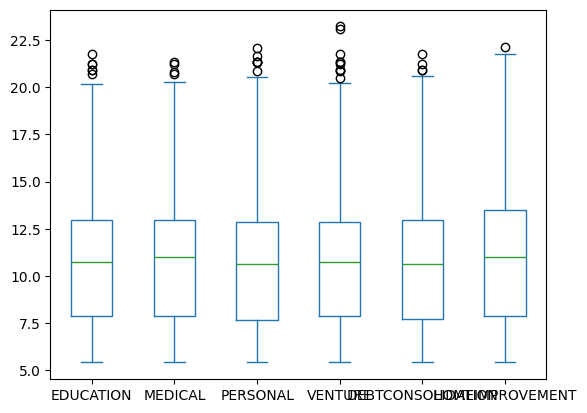

```python
#loan intention vs loan intentition rate
intention=data['loan_intent'].unique().tolist()
kum={}
for i in intention:
    dat=data[data['loan_intent']==i]['loan_int_rate']
    kum[i]=dat
df_int=pd.DataFrame(kum)
df_int.plot(kind='box')
```

based on loan intion rate for each type of intention its same value between 7.5 to 12.5, its moderate demand for banker

### Make Model Machine Learning

We want make a model machine learning to predictingn loan approval or loan status

**1. Check the distribution of loan status**

```python
tab=data['loan_status'].value_counts()
tab
```

```
loan_status
0    50295
1     8350
Name: count, dtype: int64
```

the dataset is **imbalanced** because the approval of no is more higher than approval status 1

**2. Deciding the model**

Because the data class is imbalanced, we use **XGBOOST** because this model perform better for imbalanced class

**3. prepare data**

Since the variable has different unit value, we can standarization/normalization and for categorical we can doing label encoder. Because we using XGBOOST that can handle different unit value we dont need standarization and normalzation, we just doing label encoding

```python
data_prep=data.copy()
data_prep.head()
```

|  | id | person_age | person_income | person_home_ownership | person_emp_length | loan_intent | loan_grade | loan_amnt | loan_int_rate | loan_percent_income | cb_person_default_on_file | cb_person_cred_hist_length | loan_status |
| --- | --- | --- | --- | --- | --- | --- | --- | --- | --- | --- | --- | --- | --- |
| 0 | 0 | 37 | 35000 | RENT | 0.0 | EDUCATION | B | 6000 | 11.49 | 0.17 | N | 14 | 0 |
| 1 | 1 | 22 | 56000 | OWN | 6.0 | MEDICAL | C | 4000 | 13.35 | 0.07 | N | 2 | 0 |
| 2 | 2 | 29 | 28800 | OWN | 8.0 | PERSONAL | A | 6000 | 8.90 | 0.21 | N | 10 | 0 |
| 3 | 3 | 30 | 70000 | RENT | 14.0 | VENTURE | B | 12000 | 11.11 | 0.17 | N | 5 | 0 |
| 4 | 4 | 22 | 60000 | RENT | 2.0 | MEDICAL | A | 6000 | 6.92 | 0.10 | N | 3 | 0 |

Based on dataset, the nominal variable is person home ownership and loan intent, the ordinal variable is loan grade, and boolean variable is cb person default file, we handle differently based on each type of variable

```python
#handle nominal variable
#make dummy variable
dat_nominal={}
data['person_home_ownership']=data['person_home_ownership'].apply(lambda x: x.lower())
data['loan_intent']=data['loan_intent'].apply(lambda x: x.lower())
for i in ['person_home_ownership','loan_intent']:
    kum=pd.get_dummies(data[i]).astype(int)
    dat_nominal[i]=kum
    print(kum)
dummy_vab=pd.concat([dat_nominal['person_home_ownership'],dat_nominal['loan_intent']],axis=1)
col_dummi=dummy_vab.columns.tolist()
import json
with open('columns_dummy.json','w') as f:
    json.dump(col_dummi,f)
#make label encoder
grade=data['loan_grade'].unique().tolist()
grade.sort()
map_grade={}
for i,j in zip(grade,range(len(grade))):
    map_grade[i]=j
label_grade=data['loan_grade'].map(map_grade)
label_file=data['cb_person_default_on_file'].apply(lambda x: 1 if x=='YES' else 0)
dummy_vab
```

```
       mortgage  other  own  rent
0             0      0    0     1
1             0      0    1     0
2             0      0    1     0
3             0      0    0     1
4             0      0    0     1
...         ...    ...  ...   ...
58640         1      0    0     0
58641         0      0    0     1
58642         0      0    0     1
58643         0      0    0     1
58644         1      0    0     0

[58645 rows x 4 columns]
       debtconsolidation  education  homeimprovement  medical  personal  \
```

[output cut: 26 more lines]

|  | mortgage | other | own | rent | debtconsolidation | education | homeimprovement | medical | personal | venture |
| --- | --- | --- | --- | --- | --- | --- | --- | --- | --- | --- |
| 0 | 0 | 0 | 0 | 1 | 0 | 1 | 0 | 0 | 0 | 0 |
| 1 | 0 | 0 | 1 | 0 | 0 | 0 | 0 | 1 | 0 | 0 |
| 2 | 0 | 0 | 1 | 0 | 0 | 0 | 0 | 0 | 1 | 0 |
| 3 | 0 | 0 | 0 | 1 | 0 | 0 | 0 | 0 | 0 | 1 |
| 4 | 0 | 0 | 0 | 1 | 0 | 0 | 0 | 1 | 0 | 0 |
| ... | ... | ... | ... | ... | ... | ... | ... | ... | ... | ... |
| 58640 | 1 | 0 | 0 | 0 | 0 | 1 | 0 | 0 | 0 | 0 |
| 58641 | 0 | 0 | 0 | 1 | 0 | 0 | 0 | 1 | 0 | 0 |
| 58642 | 0 | 0 | 0 | 1 | 0 | 1 | 0 | 0 | 0 | 0 |
| 58643 | 0 | 0 | 0 | 1 | 0 | 1 | 0 | 0 | 0 | 0 |
| 58644 | 1 | 0 | 0 | 0 | 0 | 0 | 0 | 0 | 0 | 1 |

58645 rows × 10 columns

```python
#drop unimportant variable
data_new=data_prep.drop(data_cat,axis=1)
data_new.drop(['id'],axis=1,inplace=True)
#merge
dat_result=pd.concat([data_new,dummy_vab,label_grade,label_file],axis=1)
dat_result
```

|  | person_age | person_income | person_emp_length | loan_amnt | loan_int_rate | loan_percent_income | cb_person_cred_hist_length | loan_status | mortgage | other | own | rent | debtconsolidation | education | homeimprovement | medical | personal | venture | loan_grade | cb_person_default_on_file |
| --- | --- | --- | --- | --- | --- | --- | --- | --- | --- | --- | --- | --- | --- | --- | --- | --- | --- | --- | --- | --- |
| 0 | 37 | 35000 | 0.0 | 6000 | 11.49 | 0.17 | 14 | 0 | 0 | 0 | 0 | 1 | 0 | 1 | 0 | 0 | 0 | 0 | 1 | 0 |
| 1 | 22 | 56000 | 6.0 | 4000 | 13.35 | 0.07 | 2 | 0 | 0 | 0 | 1 | 0 | 0 | 0 | 0 | 1 | 0 | 0 | 2 | 0 |
| 2 | 29 | 28800 | 8.0 | 6000 | 8.90 | 0.21 | 10 | 0 | 0 | 0 | 1 | 0 | 0 | 0 | 0 | 0 | 1 | 0 | 0 | 0 |
| 3 | 30 | 70000 | 14.0 | 12000 | 11.11 | 0.17 | 5 | 0 | 0 | 0 | 0 | 1 | 0 | 0 | 0 | 0 | 0 | 1 | 1 | 0 |
| 4 | 22 | 60000 | 2.0 | 6000 | 6.92 | 0.10 | 3 | 0 | 0 | 0 | 0 | 1 | 0 | 0 | 0 | 1 | 0 | 0 | 0 | 0 |
| ... | ... | ... | ... | ... | ... | ... | ... | ... | ... | ... | ... | ... | ... | ... | ... | ... | ... | ... | ... | ... |
| 58640 | 34 | 120000 | 5.0 | 25000 | 15.95 | 0.21 | 10 | 0 | 1 | 0 | 0 | 0 | 0 | 1 | 0 | 0 | 0 | 0 | 3 | 0 |
| 58641 | 28 | 28800 | 0.0 | 10000 | 12.73 | 0.35 | 8 | 1 | 0 | 0 | 0 | 1 | 0 | 0 | 0 | 1 | 0 | 0 | 2 | 0 |
| 58642 | 23 | 44000 | 7.0 | 6800 | 16.00 | 0.15 | 2 | 1 | 0 | 0 | 0 | 1 | 0 | 1 | 0 | 0 | 0 | 0 | 3 | 0 |
| 58643 | 22 | 30000 | 2.0 | 5000 | 8.90 | 0.17 | 3 | 0 | 0 | 0 | 0 | 1 | 0 | 1 | 0 | 0 | 0 | 0 | 0 | 0 |
| 58644 | 31 | 75000 | 2.0 | 15000 | 11.11 | 0.20 | 5 | 0 | 1 | 0 | 0 | 0 | 0 | 0 | 0 | 0 | 0 | 1 | 1 | 0 |

58645 rows × 20 columns

we will use hybrid approach XGBOOST (use subsample and cross-validation)

## XGBOOST

powerful machine learning moddel that use decision tree as base knowledge. WHen we dealing imbalance data class we should use this model

```python
import xgboost as xgb
from sklearn.model_selection import train_test_split
from sklearn.metrics import roc_auc_score
#define X and y
y=dat_result['loan_status']
X=dat_result[[i for i in dat_result.columns.tolist() if i !='loan_status' and i!='loan_percent_income' and i!='loan_int_rate']]
#save the model columns exclude dummy variable
#spli data into training and test data, ensure proportion of y same as original data we use stratify
Xtrain,Xtest,ytrain,ytest=train_test_split(X,y,test_size=0.2,random_state=42,stratify=y)
#split data again for validation
xtrain_n,xval,ytrain_n,yval=train_test_split(Xtrain,ytrain,test_size=0.2,random_state=42,stratify=ytrain)
X.columns.tolist()
```

```
['person_age',
 'person_income',
 'person_emp_length',
 'loan_amnt',
 'cb_person_cred_hist_length',
 'mortgage',
 'other',
 'own',
 'rent',
 'debtconsolidation',
 'education',
 'homeimprovement',
 'medical',
 'personal',
 'venture',
 'loan_grade',
 'cb_person_default_on_file']
```

### Build the model XGBOOST

Because we want make model more robust, we use croos validation to improve validation performance and subsample in every tree to avoid overfitting. Subsample is method to choose randomly from dataset.

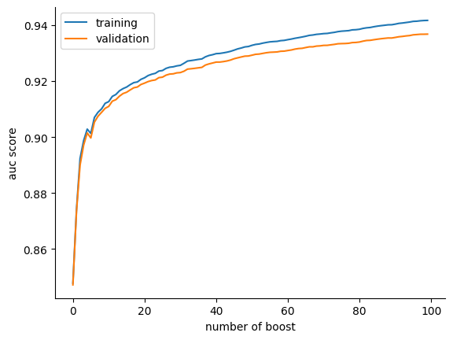

```python
#define the params
param={
    "objective":"binary:logistic", #because class  label y is binary
    "eval_metric":'auc', #evaluation metric
    'max_depth':3,
    'min_child_weight':6,
    'num_boost_round':500, #number of tree
    'subsample':0.6, #reduce overfittinh
    'colsample_bytree':0.6,
    'reg_alpha':20, #regularization L1
    'reg_lambda':50, #regularization L2
    'random_state':42,
    'scale_pos_weight':sum(ytrain==0)/sum(ytrain==1)*0.5 #adjust weight of minority class

}
#using stratified kfold since the data is imbalanced
from sklearn.model_selection import StratifiedKFold
#we shuffle before make the fold
kf=StratifiedKFold(n_splits=5,shuffle=True,random_state=42)
#convert data to xgb matrix
dtrain=xgb.DMatrix(xtrain_n, label=ytrain_n)
dval=xgb.DMatrix(xval, label=yval)
#croos validation
cv_result=xgb.cv(
    params=param,
    dtrain=dtrain,
    num_boost_round=100, #its like epochs
    folds=kf,
    verbose_eval=False,
    metrics='auc'


)
#plot the result
from matplotlib import pyplot as plt
#training dataset plot
plt.plot(cv_result['train-auc-mean'],label='training')
#validation plot
plt.plot(cv_result['test-auc-mean'],label='validation')
plt.xlabel('number of boost')
plt.ylabel('auc score')
plt.gca().spines['top'].set_visible(False)
plt.gca().spines['right'].set_visible(False)

plt.legend()
```

#### Explanantion

The model is not overfitting and the model is good because there're small gap between training and test

```python
print(cv_result.shape[0])
```

```
100
```

**Train the model**

Train the model using param that we have made before

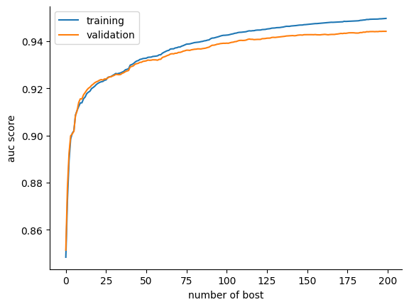

```python
train_result={}
model=xgb.train(
    params=param,
    dtrain=dtrain,
    num_boost_round=200,
    evals=[(dtrain,'train'),(dval,'validation')],
    evals_result=train_result,
    verbose_eval=False

)
from matplotlib import pyplot as plt
plt.plot(train_result['train']['auc'],label='training')
plt.plot(train_result['validation']['auc'],label='validation')
plt.xlabel('number of bost')
plt.ylabel('auc score')
plt.gca().spines['top'].set_visible(False)
plt.gca().spines['right'].set_visible(False)

plt.legend()
```

the model works well because there're small gap between trainiin and validation

## Test model using test dataset

```python
#convert to dbMatrix
dtest=xgb.DMatrix(Xtest,label=ytest)
#predict
ypred=model.predict(dtest)
#score auc-score
from sklearn.metrics import roc_auc_score,roc_curve
roc_score=roc_auc_score(ytest,ypred)
print(f"ROC-AUC score is : {roc_score}")
```

```
ROC-AUC score is : 0.9441883307646561
```

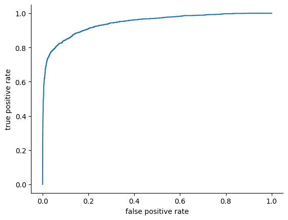

```python
#membuat roc curve
#fpr false positive rate
#tpr true positive rate
fpr,tpr,_=roc_curve(ytest,ypred)
from matplotlib import pyplot as plt
plt.plot(fpr,tpr)
plt.xlabel('false positive rate')
plt.ylabel('true positive rate')
plt.gca().spines['top'].set_visible(False)
plt.gca().spines['right'].set_visible(False)
```

Based ongraph, the model can distinguish positive and negative within imbalance data with low false positive rate, indicating auc score that we determine before is 0.94m because auc score is more than 0.9 is considered good model

# DEPLOYMENT

you can access this apss : https://zenahmad06-streamlit-file-dpl-brykqq.streamlit.app/

```python
import pickle
with open("model_approval.pkl","wb") as file:
    pickle.dump(model,file)
```